# Mosquito Traps and Rainfall in YEG

Alexander Ondrus

3/5/2020

## Loading & Manipulating Data

The two CSV files that we need for this example are the Rainfall Gauge Results and the Mosquitoes Trap Data. I also load the `tidyverse` library as well.

```r
library(tidyverse)
mosquito <- read_csv("Mosquitoes_Trap_Data__May_2011_to_Sep_2015_.csv")
rain <- read_csv("Rainfall_Gauge_Results.csv")
```

Note that the mosquito data is *weekly* and the rainfall data is *daily*. That means that I need to aggregate the rainfall data to the same frequency as the mosquito data and then join the two data frames together. Neither date column is immediately recognized as a date, so I use the `lubridate` package to set the format.

```r
library(lubridate)
mosquito$TRAP_DATE <- mdy(mosquito$TRAP_DATE)
rain$DATE <- mdy(rain$DATE)
```

The `lubridate` package also has a `week()` function that returns the week of the year for a given date. I will add these columns to both the mosquito and rain data. I also rename the `YEAR` column in the rain data to `Year` to match up with the mosquito data later on.

```r
mosquito$Year <- year(mosquito$TRAP_DATE)
mosquito$Week <- week(mosquito$TRAP_DATE)

rain$Week <- week(rain$DATE)
rain <- rename(rain, Year = YEAR)
```

To simplify things greatly, I am just going to look at the total rainfall for each week and the total number of mosquitos caught each week. This means that I only need the year, week, and total columns for each data set. Note that the data is spread over multiple rows for each set, so I will need to group and summarise the data as well. To make these commands concise, I will use the pipe operator `%>%`

```r
mosquitoes_per_week <- select(mosquito, Year, Week, TOTAL) %>%
  group_by(Year, Week) %>%
  summarise(Total_Mosquitoes = sum(TOTAL, na.rm = TRUE)) %>%
  filter(!is.na(Year), !is.na(Week))

rain_per_week <- select(rain, Year, Week, AMOUNT) %>%
  group_by(Year, Week) %>%
  summarise(Total_Rain = sum(AMOUNT, na.rm = TRUE)) %>%
  filter(!is.na(Year), !is.na(Week))
```

Now the two data sets are on the same frequency, I can merge them using an *inner join*. This means that I only include rows that have matching values in both data frames for the specified columns.

```r
mosquitoes_w_rain <- inner_join(mosquitoes_per_week, rain_per_week, by = c("Year", "Week"))
```

## Predictive Modelling

I want to predict the number of mosquitoes caught in the trap in a given week based on the total rainfall that week and the week of the year. R has many, many ways of doing this, but I will show just two. Before I do, let’s take a look at the data:

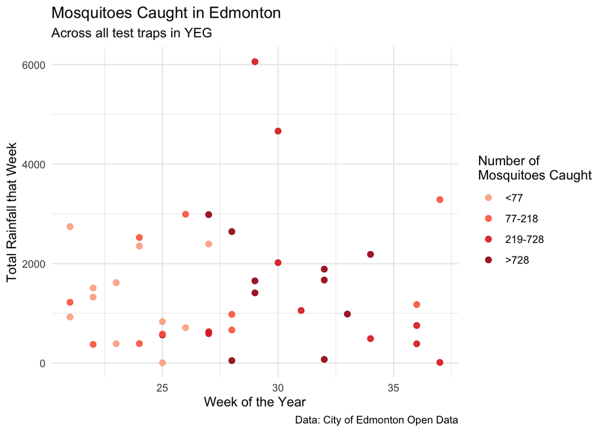

```r
mosquitoes_w_rain <- ungroup(mosquitoes_w_rain) %>%
  select(-Year)

library(RColorBrewer)
custom_palette = brewer.pal(5, "Reds")[2:5]

p <- ggplot(mosquitoes_w_rain, aes(x = Week, y = Total_Rain, colour = cut_number(Total_Mosquitoes, 4))) +
  geom_point(size = 2, alpha = 0.9) +
  scale_color_manual(values = custom_palette,
                     labels = c("<77","77-218","219-728",">728")) +
  labs(title = "Mosquitoes Caught in Edmonton",
       subtitle = "Across all test traps in YEG",
       x = "Week of the Year",
       y = "Total Rainfall that Week",
       colour = "Number of\nMosquitoes Caught",
       caption = "Data: City of Edmonton Open Data")+
  theme_minimal()

plot(p)
```

### Polynomial Regression

It is difficult to see any linear relationships in the data above, so instead I will try a polynomial regression. I do this using the `polym()` command to tell R that I want to use not only the original two variables, but their powers and intersections up to a specified degree.

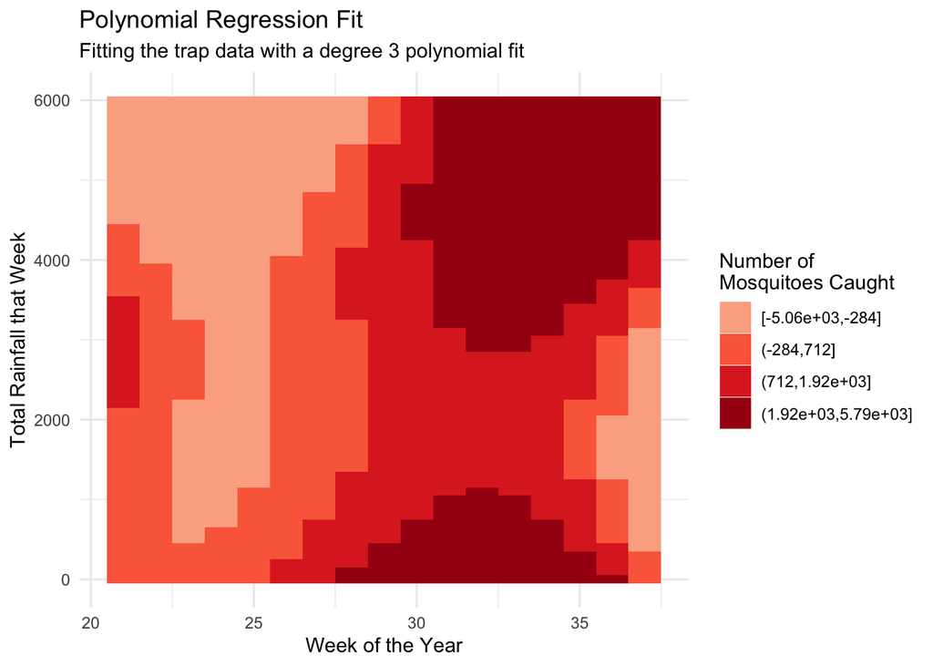

```r
mosquito_polyfit <- lm(Total_Mosquitoes ~ poly(Week, Total_Rain, degree = 3), data = mosquitoes_w_rain)

test_input <- expand.grid(min(mosquitoes_w_rain$Week):max(mosquitoes_w_rain$Week), (0:60)*100)
colnames(test_input) <- c("Week", "Total_Rain")

simulated_results <- cbind(test_input,
                           predict(mosquito_polyfit,
                                   newdata = test_input))
colnames(simulated_results)[3] <- "Total_Mosquitoes"

p1 <- ggplot(simulated_results, aes(x = Week,
                                    y = Total_Rain,
                                    fill = cut_number(Total_Mosquitoes, n = 4))) +
  geom_bin2d(stat = "identity") +
  scale_fill_manual(values = custom_palette) +
    labs(title = "Polynomial Regression Fit",
       subtitle = "Fitting the trap data with a degree 3 polynomial fit",
       x = "Week of the Year",
       y = "Total Rainfall that Week",
       fill = "Number of\nMosquitoes Caught")+
  theme_minimal()
plot(p1)
```

Taking a quick look at the legend values, it is easy to see that the polynomial regression fit does not do well at predicting the data at all.

### Regression Tree

Regression trees segment our predictor space in a manner that minimizes the variation of the output variable and uses the mean of given values to predict the output value in each region. See [here](https://en.wikipedia.org/wiki/Decision_tree_learning) for more details. The R package for building regression (or classification) trees is `tree`.

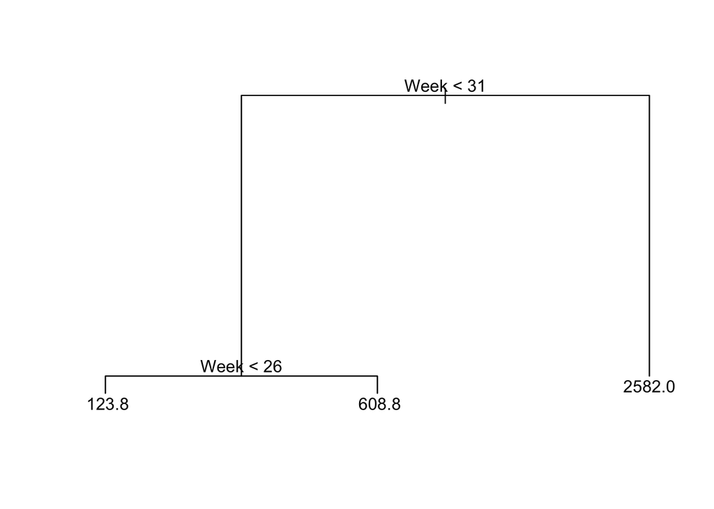

```r
library(tree)

training_rows <- sample(1:nrow(mosquitoes_w_rain),
                        floor(nrow(mosquitoes_w_rain)*0.75))

mosquito_tree <- tree(Total_Mosquitoes ~ .,
                      mosquitoes_w_rain,
                      subset = training_rows)

plot(mosquito_tree)
text(mosquito_tree, pretty = 0)
```

```r
test_data <- select(mosquitoes_w_rain[-training_rows,], -Total_Mosquitoes)
test_output <- mosquitoes_w_rain[-training_rows, "Total_Mosquitoes"]
test_predictions <- predict(mosquito_tree, newdata = test_data)
tree_mse = mean(unlist((test_predictions - test_output)^2))
```

This means that the MSE (or *M*ean *S*quared *E*rror), defined by:

$$\mathrm{MSE} = \frac{1}{n} \sum_i \left( y_{\mathrm{predicted}} - y_{\mathrm{actual}} \right)^2$$

is equal to 2 436 248 for our model. Taking the square root of this we can estimate that the model will be off by 1 561 mosquitoes. Let’s visualize the results in a way similar to linear regression.

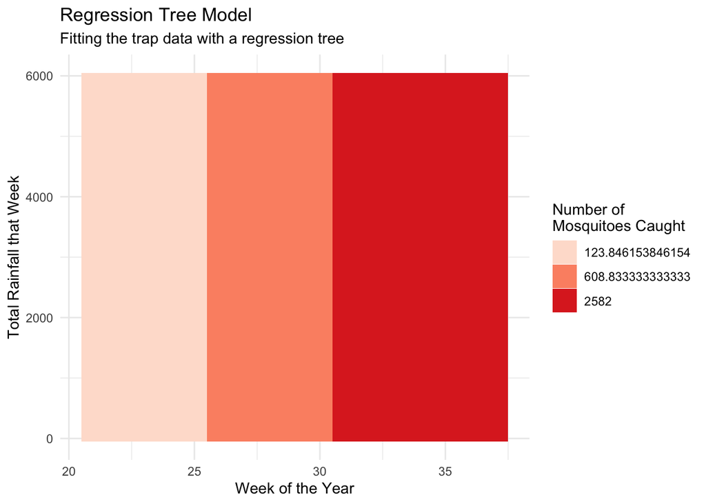

```r
simulated_tree_results <- cbind(test_input,
                           predict(mosquito_tree,
                                   newdata = test_input))
colnames(simulated_tree_results)[3] <- "Total_Mosquitoes"

p2 <- ggplot(simulated_tree_results, aes(x = Week,
                                    y = Total_Rain,
                                    fill = factor(Total_Mosquitoes))) +
  geom_bin2d(stat = "identity") +
  scale_fill_brewer(palette = "Reds") +
    labs(title = "Regression Tree Model",
       subtitle = "Fitting the trap data with a regression tree",
       x = "Week of the Year",
       y = "Total Rainfall that Week",
       fill = "Number of\nMosquitoes Caught")+
  theme_minimal()
plot(p2)
```